# DN19023-ax343

Robert Goldstone

2022-08-22

# Project description

The JH4 intron within the immunoglobulin locus is subject to somatic hypermutation and therefore varies in sequence compared with the germline / reference.

This locus has been amplified as a 433 bp amplicon and sequenced with 2x250 bp PE reads

The goal is to align the reads with the reference sequence, quantify the number of mutations per amplicon, plot a distribution of mutational load within each sample, then compare the distribution between samples.

## Tasks:

1. Align with reference sequence
2. Quantify number of mutations per sample
3. Plot distribution of mutations load within each sample
4. Compare the distribution between samples

# Set up R for this work

```r
library(readr)
library(ggplot2)
library(seqinr)
library(CrispRVariants)
library(glue)
library(Biostrings)
library(pheatmap)
library(GenomicRanges)
library(Rsamtools)
library(ShortRead)
library(msa)
library(tidyverse)
library(waldo)
library(vcfR)
library(stringdist)
library(ape)
library(ggrepel)
library(data.table)
```

# Analysis

We’ll go through a couple of strategies in this report for investigating this. For all the methods, we’ll want to merge the paired end reads from our sequencing into one read for each pair that covers the amplicon.

### Step 1 - combine the reads into a consensus read.

This step involved using the commandline program bbtool. In the bbtools package, there is a function called bbmerge that overlaps reads into consensus reads

```bash
#!/usr/bin/bash

module purge
module load Miniconda3/4.7.10
conda activate bbtools

bbmerge.sh in=$read1.fastq.gz in2=$read2.fastq.gz out= merged_reads/$sample.fastq.gz
```

This produced a folder containing the consesnus reads for each sample

`merged_reads/*`

## Approach 1 - using CrispRVariants

CrispRVariants is an R package that characterises variants in amplicon data. However, it seems to be best at detecting mutant clones in data referenced to a guide RNA location. It is not so easy to use it to count unique SNP variants within the population

## Step 1.1 producing a reference file for CrispRVariants

The CrispRVariants R package requires a reference sequence for the region you are interested in so to call mutations. To produce this reference sequence, we use samtools faidx

```bash
module purge
module load SAMtools/1.13-GCC-10.2.0
samtools faidx $reference.fa 12:113428106-113428538 > reference.fasta
```

## Step 1.2 setting up a samplesheet for CrispRVariants

```r
info_file <- read.csv('samplesheet.csv')
knitr::kable(info_file)
```

| sample | gene | seq | chr | start | end | strand | plus | minus |
| --- | --- | --- | --- | --- | --- | --- | --- | --- |
| DCKP93B_BM_5DPOG | JH4 | ccccactcca | 12 | 113428106 | 113428538 | + | 0 | 0 |
| DCKP103B_BM_5DPOG | JH4 | ccccactcca | 12 | 113428106 | 113428538 | + | 0 | 0 |
| DCKP141F_BM_5DPOG | JH4 | ccccactcca | 12 | 113428106 | 113428538 | + | 0 | 0 |
| DCKP141G_BM_5DPOG | JH4 | ccccactcca | 12 | 113428106 | 113428538 | + | 0 | 0 |
| DCKP106C_BM_5DPOG | JH4 | ccccactcca | 12 | 113428106 | 113428538 | + | 0 | 0 |
| DCKP141A_BM_5DPOG | JH4 | ccccactcca | 12 | 113428106 | 113428538 | + | 0 | 0 |
| DCKP141F_SP_5DPOG | JH4 | ccccactcca | 12 | 113428106 | 113428538 | + | 0 | 0 |
| DCKP141G_SP_5DPOG | JH4 | ccccactcca | 12 | 113428106 | 113428538 | + | 0 | 0 |
| DCKP106C_SP_5DPOG | JH4 | ccccactcca | 12 | 113428106 | 113428538 | + | 0 | 0 |
| DCKP141A_SP_5DPOG | JH4 | ccccactcca | 12 | 113428106 | 113428538 | + | 0 | 0 |
| DCKP93C_BM_2MPOG | JH4 | ccccactcca | 12 | 113428106 | 113428538 | + | 0 | 0 |
| DCKP93D_BM_2MPOG | JH4 | ccccactcca | 12 | 113428106 | 113428538 | + | 0 | 0 |
| DCKP141E_BM_2MPOG | JH4 | ccccactcca | 12 | 113428106 | 113428538 | + | 0 | 0 |
| DCKP141D_BM_2MPOG | JH4 | ccccactcca | 12 | 113428106 | 113428538 | + | 0 | 0 |
| DCKP141B_BM_2MPOG | JH4 | ccccactcca | 12 | 113428106 | 113428538 | + | 0 | 0 |
| DCKP141E_SP_2MPOG | JH4 | ccccactcca | 12 | 113428106 | 113428538 | + | 0 | 0 |
| DCKP141D_SP_2MPOG | JH4 | ccccactcca | 12 | 113428106 | 113428538 | + | 0 | 0 |
| DCKP141C_SP_2MPOG | JH4 | ccccactcca | 12 | 113428106 | 113428538 | + | 0 | 0 |
| DCKP141B_SP_2MPOG | JH4 | ccccactcca | 12 | 113428106 | 113428538 | + | 0 | 0 |
| DCKP151B_BM_4MPOG | JH4 | ccccactcca | 12 | 113428106 | 113428538 | + | 0 | 0 |
| DCKP141I_BM_4MPOG | JH4 | ccccactcca | 12 | 113428106 | 113428538 | + | 0 | 0 |
| DCKP141H_BM_4MPOG | JH4 | ccccactcca | 12 | 113428106 | 113428538 | + | 0 | 0 |
| DCKP151B_SP_4MPOG | JH4 | ccccactcca | 12 | 113428106 | 113428538 | + | 0 | 0 |
| DCKP141I_SP_4MPOG | JH4 | ccccactcca | 12 | 113428106 | 113428538 | + | 0 | 0 |
| DCKP141H_SP_4MPOG | JH4 | ccccactcca | 12 | 113428106 | 113428538 | + | 0 | 0 |
| DCKP92E_BM_5MPOG | JH4 | ccccactcca | 12 | 113428106 | 113428538 | + | 0 | 0 |
| DCKP92f_BM_5MPOG | JH4 | ccccactcca | 12 | 113428106 | 113428538 | + | 0 | 0 |
| DCKP92g_BM_5MPOG | JH4 | ccccactcca | 12 | 113428106 | 113428538 | + | 0 | 0 |
| DCKP92h_BM_5MPOG | JH4 | ccccactcca | 12 | 113428106 | 113428538 | + | 0 | 0 |
| DCKP92e_SP_5MPOG | JH4 | ccccactcca | 12 | 113428106 | 113428538 | + | 0 | 0 |
| DCKP92f_SP_5MPOG | JH4 | ccccactcca | 12 | 113428106 | 113428538 | + | 0 | 0 |
| DCKP92g_SP_5MPOG | JH4 | ccccactcca | 12 | 113428106 | 113428538 | + | 0 | 0 |
| DCKP92h_SP_5MPOG | JH4 | ccccactcca | 12 | 113428106 | 113428538 | + | 0 | 0 |
| DCKP103A_SP_9MPOG | JH4 | ccccactcca | 12 | 113428106 | 113428538 | + | 0 | 0 |
| DCKP103C_SP_9MPOG | JH4 | ccccactcca | 12 | 113428106 | 113428538 | + | 0 | 0 |
| DCKP103D_SP_9MPOG | JH4 | ccccactcca | 12 | 113428106 | 113428538 | + | 0 | 0 |
| DCKP106E_SP_9MPOG | JH4 | ccccactcca | 12 | 113428106 | 113428538 | + | 0 | 0 |
| DCKP106F_SP_9MPOG | JH4 | ccccactcca | 12 | 113428106 | 113428538 | + | 0 | 0 |
| DCKP151C_SP_9MPOG | JH4 | ccccactcca | 12 | 113428106 | 113428538 | + | 0 | 0 |
| DCKP106E_BM_9MPOG | JH4 | ccccactcca | 12 | 113428106 | 113428538 | + | 0 | 0 |
| DCKP106F_BM_9MPOG | JH4 | ccccactcca | 12 | 113428106 | 113428538 | + | 0 | 0 |
| DCKP151C_BM_9MPOG | JH4 | ccccactcca | 12 | 113428106 | 113428538 | + | 0 | 0 |
| DCKP251A_SP_POSCTRL | JH4 | ccccactcca | 12 | 113428106 | 113428538 | + | 0 | 0 |
| DCKP251B_SP_POSCTRL | JH4 | ccccactcca | 12 | 113428106 | 113428538 | + | 0 | 0 |
| DCKP251C_SP_POSCTRL | JH4 | ccccactcca | 12 | 113428106 | 113428538 | + | 0 | 0 |
| DCKP212E_SP_NEGCTRL | JH4 | ccccactcca | 12 | 113428106 | 113428538 | + | 0 | 0 |
| DCKP223H_SP_NEGCTRL | JH4 | ccccactcca | 12 | 113428106 | 113428538 | + | 0 | 0 |
| DCKP223I_SP_NEGCTRL | JH4 | ccccactcca | 12 | 113428106 | 113428538 | + | 0 | 0 |

## Step 1.3 using CrispRVariants to assess mutational frequency in the amplicon data

For this step, there we need to read in the reference fasta file that we made

```r
reference <- read.fasta(file ="reference.fasta", as.string = T)
reference <- DNAString(unlist(reference))
print(reference)
```

```
## 433-letter DNAString object
## seq: CCCCACTCCACTCTTTGTCCCTATGCATCGGATACT...GCCATTCTTACCTGAGGAGACGGTGACTGAGGTTCC
```

With that fasta now loaded into R, we can loop through our samples and build a matrix of mutational load

```r
my.results <- list()  # create a list to store our results in

for (i in 1:length(info_file$sample)) { # for every sample in info_file
  ref.to.use <- reference # grab the reference
  if (info_file$strand[i] == "-") { # reverse complement the reference if we need to
    ref.to.use <- reverseComplement(reference) # reverse complement the reference if we need to
  } # reverse complement the reference if we need to
  bam <- glue("{working.dir}merged_read_bam/{info_file$sample[i]}.bam") # build a file name for the bam file that belongs to this sample
  region <- GRanges(seqnames = info_file$chr[i], ranges = IRanges(info_file$start[i], info_file$end[i]), strand = info_file$strand[i]) # tell CrispRVariants what region of the genome we want to profile
  crispr_set <- readsToTarget(bam, region ,chimeras = 'exclude', reference = ref.to.use, target.loc = 0, ignore.strand = T) # run readsTotarget that does the mutation profiling
  if (is.null(crispr_set)) { # we check if it's null because some samples have no reads?
    my.results[[i]] <- NULL
  } else { # if there is information in crispr_set (there was some reads mapping to the target)
   var_counts <- variantCounts(crispr_set, result="counts", include.nonindel = T) # count the variants
   my.results[[i]] <- var_counts # store those counts in our results
  }
}

names(my.results) <- info_file$sample # just make the results of our loop have nice names
```

Next, we will just collapse the list of results into a table

```r
my.output <- data.frame(my.results[[1]])

for (i in 2:length(my.results)) {
  my.output <- merge(my.output, my.results[[i]], by = 0, all = TRUE)
  rownames(my.output) <- my.output$Row.names
  my.output <- my.output[,-1]
}
# this will contain lots of NAs, but NA means 0 here, so we can replace NAs with 0

my.output[is.na(my.output)] <- 0
colnames(my.output) <- gsub('.bam', '', colnames(my.output))

my.output <- t(my.output) # transpose it because the axis are the wrong way around

knitr::kable(my.output)
```

|  | 10:1D | 10:1D,266:1D | 10:1D,421:1D | 10:1D,421:3D | 10:1D,422:1D | 10:1D,424:1D | 10:1D,57:1D | 10:1I | 10:3D | 10:3D,422:1D | 103:1D | 103:1I | 103:1I,419:1D | 109:1D | 11:1D | 11:1D,149:1D | 11:1D,202:1D | 11:1D,284:26D | 11:1D,425:1D | 11:1I | 110:1D | 112:1D | 114:1D | 115:1D | 118:1D | 12:1D | 12:1D,188:1D | 12:1D,196:1D | 12:1D,199:1D | … |
| --- | --- | --- | --- | --- | --- | --- | --- | --- | --- | --- | --- | --- | --- | --- | --- | --- | --- | --- | --- | --- | --- | --- | --- | --- | --- | --- | --- | --- | --- | --- |
| DCKP93B_BM_5DPOG | 2 | 0 | 0 | 0 | 0 | 0 | 0 | 0 | 0 | 0 | 0 | 0 | 0 | 0 | 2 | 0 | 0 | 0 | 1 | 0 | 0 | 0 | 0 | 0 | 0 | 11 | 0 | 0 | 0 | … |
| DCKP103B_BM_5DPOG | 5 | 0 | 0 | 0 | 1 | 0 | 0 | 0 | 1 | 0 | 0 | 0 | 0 | 0 | 8 | 0 | 0 | 0 | 0 | 0 | 0 | 0 | 0 | 0 | 0 | 10 | 0 | 0 | 0 | … |
| DCKP141F_BM_5DPOG | 5 | 0 | 0 | 0 | 0 | 0 | 0 | 0 | 0 | 0 | 1 | 0 | 0 | 0 | 2 | 0 | 0 | 0 | 0 | 0 | 0 | 0 | 0 | 0 | 0 | 10 | 0 | 0 | 0 | … |
| DCKP141G_BM_5DPOG | 1 | 0 | 0 | 0 | 0 | 0 | 0 | 1 | 0 | 0 | 1 | 0 | 0 | 0 | 4 | 0 | 0 | 0 | 0 | 0 | 1 | 0 | 0 | 0 | 0 | 11 | 0 | 0 | 0 | … |
| DCKP106C_BM_5DPOG | 1 | 0 | 0 | 0 | 0 | 0 | 0 | 1 | 0 | 0 | 1 | 0 | 0 | 0 | 3 | 0 | 0 | 0 | 0 | 0 | 0 | 0 | 1 | 0 | 0 | 9 | 0 | 0 | 0 | … |
| DCKP141A_BM_5DPOG | 2 | 0 | 0 | 0 | 0 | 0 | 0 | 1 | 0 | 0 | 0 | 0 | 0 | 0 | 5 | 0 | 0 | 0 | 0 | 0 | 0 | 0 | 0 | 0 | 0 | 10 | 0 | 0 | 0 | … |
| DCKP141F_SP_5DPOG | 2 | 0 | 0 | 0 | 0 | 0 | 0 | 0 | 0 | 0 | 0 | 0 | 0 | 0 | 2 | 0 | 0 | 0 | 0 | 1 | 0 | 0 | 0 | 0 | 0 | 12 | 0 | 0 | 0 | … |
| DCKP141G_SP_5DPOG | 0 | 0 | 0 | 0 | 0 | 0 | 0 | 0 | 0 | 0 | 0 | 0 | 0 | 0 | 3 | 0 | 1 | 0 | 0 | 0 | 0 | 0 | 0 | 0 | 0 | 7 | 0 | 0 | 0 | … |
| DCKP106C_SP_5DPOG | 2 | 0 | 0 | 0 | 0 | 0 | 0 | 0 | 0 | 0 | 0 | 0 | 0 | 0 | 2 | 0 | 0 | 0 | 0 | 0 | 0 | 0 | 0 | 0 | 0 | 5 | 0 | 0 | 0 | … |
| DCKP141A_SP_5DPOG | 0 | 0 | 0 | 0 | 0 | 1 | 0 | 0 | 0 | 0 | 0 | 0 | 0 | 0 | 5 | 0 | 0 | 0 | 0 | 0 | 0 | 0 | 0 | 0 | 0 | 8 | 0 | 0 | 0 | … |
| DCKP93C_BM_2MPOG | 4 | 0 | 0 | 0 | 0 | 0 | 0 | 1 | 0 | 0 | 2 | 0 | 0 | 0 | 6 | 0 | 0 | 1 | 0 | 0 | 0 | 0 | 0 | 0 | 0 | 19 | 0 | 0 | 0 | … |
| DCKP93D_BM_2MPOG | 2 | 0 | 0 | 0 | 0 | 0 | 0 | 1 | 0 | 0 | 0 | 0 | 0 | 0 | 5 | 0 | 0 | 0 | 0 | 0 | 0 | 0 | 0 | 0 | 0 | 13 | 0 | 0 | 0 | … |
| DCKP141E_BM_2MPOG | 2 | 0 | 0 | 0 | 0 | 0 | 0 | 0 | 1 | 1 | 3 | 1 | 0 | 0 | 7 | 0 | 0 | 0 | 0 | 0 | 0 | 0 | 0 | 0 | 0 | 19 | 0 | 1 | 0 | … |
| DCKP141D_BM_2MPOG | 4 | 0 | 0 | 1 | 0 | 0 | 0 | 1 | 0 | 0 | 1 | 0 | 0 | 0 | 6 | 0 | 0 | 0 | 1 | 0 | 1 | 0 | 0 | 0 | 0 | 15 | 0 | 0 | 1 | … |
| DCKP141B_BM_2MPOG | 1 | 0 | 0 | 0 | 0 | 0 | 0 | 1 | 0 | 0 | 0 | 0 | 0 | 0 | 4 | 0 | 0 | 0 | 0 | 0 | 0 | 1 | 0 | 0 | 1 | 15 | 0 | 0 | 0 | … |
| DCKP141E_SP_2MPOG | 2 | 0 | 0 | 0 | 0 | 0 | 0 | 1 | 1 | 0 | 2 | 0 | 1 | 1 | 4 | 0 | 0 | 0 | 0 | 0 | 0 | 0 | 0 | 0 | 0 | 14 | 1 | 0 | 0 | … |
| DCKP141D_SP_2MPOG | 2 | 0 | 0 | 0 | 0 | 0 | 1 | 0 | 0 | 0 | 3 | 0 | 0 | 0 | 3 | 0 | 0 | 0 | 0 | 0 | 0 | 0 | 0 | 0 | 0 | 17 | 0 | 0 | 0 | … |
| DCKP141C_SP_2MPOG | 0 | 0 | 0 | 0 | 0 | 0 | 0 | 0 | 0 | 0 | 1 | 0 | 0 | 0 | 6 | 0 | 0 | 0 | 0 | 0 | 1 | 0 | 0 | 0 | 0 | 15 | 0 | 0 | 0 | … |
| DCKP141B_SP_2MPOG | 4 | 0 | 0 | 0 | 0 | 0 | 0 | 1 | 0 | 0 | 1 | 0 | 0 | 0 | 3 | 0 | 0 | 0 | 0 | 0 | 1 | 0 | 0 | 0 | 0 | 15 | 0 | 0 | 0 | … |
| DCKP151B_BM_4MPOG | 3 | 0 | 1 | 0 | 0 | 0 | 0 | 0 | 0 | 0 | 0 | 0 | 0 | 0 | 8 | 0 | 0 | 0 | 0 | 0 | 0 | 0 | 0 | 0 | 0 | 13 | 0 | 0 | 0 | … |
| DCKP141I_BM_4MPOG | 4 | 0 | 0 | 0 | 0 | 0 | 0 | 0 | 0 | 0 | 0 | 0 | 0 | 0 | 3 | 0 | 0 | 0 | 0 | 1 | 0 | 0 | 0 | 0 | 0 | 12 | 0 | 0 | 0 | … |
| DCKP141H_BM_4MPOG | 1 | 0 | 0 | 0 | 0 | 0 | 0 | 0 | 0 | 0 | 1 | 0 | 0 | 0 | 1 | 0 | 0 | 0 | 0 | 0 | 0 | 0 | 0 | 0 | 0 | 10 | 0 | 0 | 0 | … |
| DCKP151B_SP_4MPOG | 2 | 0 | 0 | 0 | 0 | 0 | 0 | 0 | 0 | 0 | 0 | 0 | 0 | 0 | 0 | 1 | 0 | 0 | 0 | 0 | 0 | 0 | 0 | 0 | 0 | 11 | 0 | 0 | 0 | … |
| DCKP141I_SP_4MPOG | 0 | 0 | 0 | 0 | 0 | 0 | 0 | 0 | 0 | 0 | 0 | 0 | 0 | 0 | 3 | 0 | 0 | 0 | 0 | 0 | 0 | 0 | 0 | 0 | 0 | 9 | 0 | 0 | 0 | … |
| DCKP141H_SP_4MPOG | 3 | 0 | 0 | 0 | 0 | 0 | 0 | 0 | 0 | 0 | 0 | 0 | 0 | 0 | 2 | 0 | 0 | 0 | 0 | 0 | 0 | 0 | 0 | 0 | 0 | 17 | 0 | 0 | 0 | … |
| DCKP92E_BM_5MPOG | 0 | 0 | 0 | 0 | 0 | 0 | 0 | 0 | 0 | 0 | 0 | 0 | 0 | 0 | 0 | 0 | 0 | 0 | 0 | 0 | 0 | 0 | 0 | 0 | 0 | 0 | 0 | 0 | 0 | … |
| DCKP92f_BM_5MPOG | 0 | 0 | 0 | 0 | 0 | 0 | 0 | 0 | 0 | 0 | 0 | 0 | 0 | 0 | 0 | 0 | 0 | 0 | 0 | 0 | 0 | 0 | 0 | 0 | 0 | 0 | 0 | 0 | 0 | … |
| DCKP92g_BM_5MPOG | 1 | 1 | 0 | 0 | 0 | 0 | 0 | 0 | 0 | 0 | 1 | 0 | 0 | 0 | 3 | 0 | 0 | 0 | 0 | 0 | 0 | 0 | 0 | 0 | 0 | 14 | 0 | 0 | 0 | … |
| DCKP92h_BM_5MPOG | 0 | 0 | 0 | 0 | 0 | 0 | 0 | 0 | 0 | 0 | 0 | 0 | 0 | 0 | 0 | 0 | 0 | 0 | 0 | 0 | 0 | 0 | 0 | 0 | 0 | 1 | 0 | 0 | 0 | … |
| DCKP92e_SP_5MPOG | 1 | 0 | 0 | 0 | 0 | 0 | 0 | 0 | 0 | 0 | 0 | 0 | 0 | 0 | 0 | 0 | 0 | 0 | 0 | 0 | 0 | 0 | 0 | 0 | 0 | 0 | 0 | 0 | 0 | … |
| DCKP92g_SP_5MPOG | 0 | 0 | 0 | 0 | 0 | 0 | 0 | 0 | 0 | 0 | 0 | 0 | 0 | 0 | 0 | 0 | 0 | 0 | 0 | 0 | 0 | 0 | 0 | 0 | 0 | 0 | 0 | 0 | 0 | … |
| DCKP92h_SP_5MPOG | 0 | 0 | 0 | 0 | 0 | 0 | 0 | 0 | 0 | 0 | 0 | 0 | 0 | 0 | 0 | 0 | 0 | 0 | 0 | 0 | 0 | 0 | 0 | 0 | 0 | 2 | 0 | 0 | 0 | … |
| DCKP103A_SP_9MPOG | 0 | 0 | 0 | 0 | 0 | 0 | 0 | 0 | 0 | 0 | 0 | 0 | 0 | 0 | 0 | 0 | 0 | 0 | 0 | 0 | 0 | 0 | 0 | 0 | 0 | 5 | 0 | 0 | 0 | … |
| DCKP103C_SP_9MPOG | 1 | 0 | 0 | 0 | 0 | 0 | 0 | 0 | 0 | 0 | 0 | 0 | 0 | 0 | 1 | 0 | 0 | 0 | 0 | 0 | 0 | 0 | 0 | 0 | 0 | 9 | 0 | 0 | 0 | … |
| DCKP103D_SP_9MPOG | 0 | 0 | 0 | 0 | 0 | 0 | 0 | 0 | 0 | 0 | 0 | 0 | 0 | 0 | 0 | 0 | 0 | 0 | 0 | 0 | 0 | 0 | 0 | 0 | 0 | 0 | 0 | 0 | 0 | … |
| DCKP106E_SP_9MPOG | 0 | 0 | 0 | 0 | 0 | 0 | 0 | 0 | 0 | 0 | 0 | 0 | 0 | 0 | 0 | 0 | 0 | 0 | 0 | 0 | 0 | 0 | 0 | 0 | 0 | 0 | 0 | 0 | 0 | … |
| DCKP106F_SP_9MPOG | 0 | 0 | 0 | 0 | 0 | 0 | 0 | 0 | 0 | 0 | 0 | 0 | 0 | 0 | 0 | 0 | 0 | 0 | 0 | 0 | 0 | 0 | 0 | 0 | 0 | 0 | 0 | 0 | 0 | … |
| DCKP151C_SP_9MPOG | 2 | 0 | 0 | 0 | 0 | 0 | 0 | 0 | 0 | 0 | 0 | 0 | 0 | 0 | 1 | 0 | 0 | 0 | 0 | 0 | 0 | 0 | 0 | 0 | 0 | 2 | 0 | 0 | 0 | … |
| DCKP106E_BM_9MPOG | 0 | 0 | 0 | 0 | 0 | 0 | 0 | 0 | 0 | 0 | 1 | 0 | 0 | 0 | 0 | 0 | 0 | 0 | 0 | 0 | 0 | 0 | 0 | 0 | 0 | 0 | 0 | 0 | 0 | … |
| DCKP106F_BM_9MPOG | 4 | 0 | 0 | 0 | 0 | 0 | 0 | 1 | 0 | 0 | 0 | 0 | 0 | 0 | 3 | 0 | 0 | 0 | 0 | 0 | 0 | 0 | 0 | 0 | 0 | 15 | 0 | 0 | 0 | … |
| DCKP151C_BM_9MPOG | 0 | 0 | 0 | 0 | 0 | 0 | 0 | 0 | 0 | 0 | 0 | 0 | 0 | 0 | 0 | 0 | 0 | 0 | 0 | 0 | 0 | 0 | 0 | 0 | 0 | 0 | 0 | 0 | 0 | … |
| DCKP251A_SP_POSCTRL | 0 | 0 | 0 | 0 | 0 | 0 | 0 | 1 | 1 | 0 | 0 | 0 | 0 | 0 | 5 | 0 | 0 | 0 | 0 | 0 | 0 | 0 | 0 | 0 | 0 | 12 | 0 | 0 | 0 | … |
| DCKP251B_SP_POSCTRL | 0 | 0 | 0 | 0 | 0 | 0 | 0 | 0 | 0 | 0 | 2 | 0 | 0 | 0 | 4 | 0 | 0 | 0 | 0 | 0 | 0 | 0 | 0 | 0 | 0 | 12 | 0 | 0 | 0 | … |
| DCKP251C_SP_POSCTRL | 1 | 0 | 0 | 0 | 0 | 0 | 0 | 0 | 0 | 0 | 0 | 0 | 0 | 0 | 1 | 0 | 0 | 0 | 0 | 0 | 0 | 0 | 0 | 0 | 0 | 3 | 0 | 0 | 0 | … |
| DCKP212E_SP_NEGCTRL | 1 | 0 | 0 | 0 | 0 | 0 | 0 | 0 | 0 | 0 | 1 | 0 | 0 | 0 | 2 | 0 | 0 | 0 | 0 | 0 | 0 | 0 | 0 | 0 | 0 | 10 | 0 | 0 | 0 | … |
| DCKP223H_SP_NEGCTRL | 0 | 0 | 0 | 0 | 0 | 0 | 0 | 0 | 0 | 0 | 0 | 0 | 0 | 0 | 2 | 0 | 0 | 0 | 0 | 0 | 0 | 0 | 0 | 0 | 0 | 3 | 0 | 0 | 0 | … |
| DCKP223I_SP_NEGCTRL | 1 | 0 | 0 | 0 | 0 | 0 | 0 | 1 | 0 | 0 | 0 | 0 | 0 | 0 | 3 | 0 | 0 | 0 | 0 | 1 | 0 | 0 | 0 | 1 | 0 | 10 | 0 | 0 | 0 | … |

Now we can plot the number of variants found.

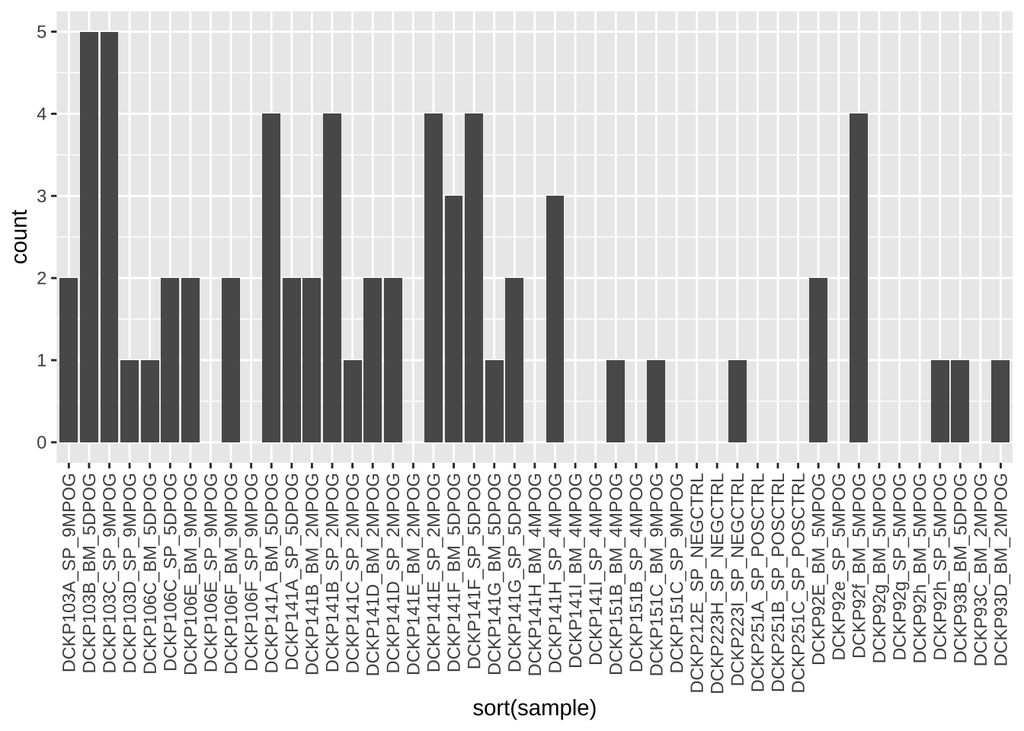

```r
  # the table of counts includes the count for 'no variant' so we want to remove that when we're counting

  my.crispr.counts <- as.data.frame(cbind(rownames(my.output), my.output[,-which(colnames(my.output) == "no variant")]))

  colnames(my.crispr.counts) <- c('sample', 'count')
  my.crispr.counts$count <- as.numeric(my.crispr.counts$count)

  ggplot(my.crispr.counts, aes(x=sort(sample), y=count)) +
  geom_bar(stat="identity") +
  theme(axis.text.x = element_text(angle = 90, vjust = 0.5, hjust=1))
```

The number of variants detected here is quite low. I think this is because CrispRVariants isn’t doing exactly what we want. Firstly, rather than counting individual mutations, CrispRVariants seems to be counting mutation patterns within reads. Secondly, CrispRVariants will only count a read that completely spans the target site, meaning that mutations at the 5’ or 3’ extreme won’t be counted.

In any case, we’ll save these counts in case the output is useful later

```r
write.csv(my.output, 'r_output_files/crisprvariant_variant_count.csv')
```

Given these limitations, we’ll instead try to use a proper variant caller.

# Approach 2 - mapping to reference and using a variant caller to define mutations

For approach 2 we’ll use traditional variant calling mapping the reads to the mouse genome. Here, we’ll map the reads to the mouse genome using bwa mem and then use the somatic variant caller Mutect2 to make the vcf.

## 2.1: mapping to genome

The consensus reads are then mapped to the mouse genome using bwa mem

```bash
#!/usr/bin/bash

module purge
module load BWA/0.7.17-foss-2018a
module load SAMtools/1.13-GCC-10.2.0

bwa mem -t 4 \
  $reference.fa \
  $sample_R1_001.fastq.gz \
  $sample_R2_001.fastq.gz |  \
  samtools view -b - | \
  samtools sort - -o bam/$sample.bam

samtools index $sample.bam
```

This resulted in the generation of several bam files that contains the mapped reads and mapping information

`bam/*`

Lets take a look at the number of mapped reads in the bam files

```r
# read in the list of bam files

filenames <- list.files("/Volumes/babs/working/goldstr2/projects/caladod/anqi.xu/DN19023-ax343/merged_read_bam", pattern="*.bam$", full.names=TRUE)
knitr::kable(filenames)
```

| x |
| --- |
| /Volumes/babs/working/goldstr2/projects/caladod/anqi.xu/DN19023-ax343/merged_read_bam/DCKP103A_SP_9MPOG.bam |
| /Volumes/babs/working/goldstr2/projects/caladod/anqi.xu/DN19023-ax343/merged_read_bam/DCKP103B_BM_5DPOG.bam |
| /Volumes/babs/working/goldstr2/projects/caladod/anqi.xu/DN19023-ax343/merged_read_bam/DCKP103C_SP_9MPOG.bam |
| /Volumes/babs/working/goldstr2/projects/caladod/anqi.xu/DN19023-ax343/merged_read_bam/DCKP103D_SP_9MPOG.bam |
| /Volumes/babs/working/goldstr2/projects/caladod/anqi.xu/DN19023-ax343/merged_read_bam/DCKP106C_BM_5DPOG.bam |
| /Volumes/babs/working/goldstr2/projects/caladod/anqi.xu/DN19023-ax343/merged_read_bam/DCKP106C_SP_5DPOG.bam |
| /Volumes/babs/working/goldstr2/projects/caladod/anqi.xu/DN19023-ax343/merged_read_bam/DCKP106E_BM_9MPOG.bam |
| /Volumes/babs/working/goldstr2/projects/caladod/anqi.xu/DN19023-ax343/merged_read_bam/DCKP106E_SP_9MPOG.bam |
| /Volumes/babs/working/goldstr2/projects/caladod/anqi.xu/DN19023-ax343/merged_read_bam/DCKP106F_BM_9MPOG.bam |
| /Volumes/babs/working/goldstr2/projects/caladod/anqi.xu/DN19023-ax343/merged_read_bam/DCKP106F_SP_9MPOG.bam |
| /Volumes/babs/working/goldstr2/projects/caladod/anqi.xu/DN19023-ax343/merged_read_bam/DCKP141A_BM_5DPOG.bam |
| /Volumes/babs/working/goldstr2/projects/caladod/anqi.xu/DN19023-ax343/merged_read_bam/DCKP141A_SP_5DPOG.bam |
| /Volumes/babs/working/goldstr2/projects/caladod/anqi.xu/DN19023-ax343/merged_read_bam/DCKP141B_BM_2MPOG.bam |
| /Volumes/babs/working/goldstr2/projects/caladod/anqi.xu/DN19023-ax343/merged_read_bam/DCKP141B_SP_2MPOG.bam |
| /Volumes/babs/working/goldstr2/projects/caladod/anqi.xu/DN19023-ax343/merged_read_bam/DCKP141C_SP_2MPOG.bam |
| /Volumes/babs/working/goldstr2/projects/caladod/anqi.xu/DN19023-ax343/merged_read_bam/DCKP141D_BM_2MPOG.bam |
| /Volumes/babs/working/goldstr2/projects/caladod/anqi.xu/DN19023-ax343/merged_read_bam/DCKP141D_SP_2MPOG.bam |
| /Volumes/babs/working/goldstr2/projects/caladod/anqi.xu/DN19023-ax343/merged_read_bam/DCKP141E_BM_2MPOG.bam |
| /Volumes/babs/working/goldstr2/projects/caladod/anqi.xu/DN19023-ax343/merged_read_bam/DCKP141E_SP_2MPOG.bam |
| /Volumes/babs/working/goldstr2/projects/caladod/anqi.xu/DN19023-ax343/merged_read_bam/DCKP141F_BM_5DPOG.bam |
| /Volumes/babs/working/goldstr2/projects/caladod/anqi.xu/DN19023-ax343/merged_read_bam/DCKP141F_SP_5DPOG.bam |
| /Volumes/babs/working/goldstr2/projects/caladod/anqi.xu/DN19023-ax343/merged_read_bam/DCKP141G_BM_5DPOG.bam |
| /Volumes/babs/working/goldstr2/projects/caladod/anqi.xu/DN19023-ax343/merged_read_bam/DCKP141G_SP_5DPOG.bam |
| /Volumes/babs/working/goldstr2/projects/caladod/anqi.xu/DN19023-ax343/merged_read_bam/DCKP141H_BM_4MPOG.bam |
| /Volumes/babs/working/goldstr2/projects/caladod/anqi.xu/DN19023-ax343/merged_read_bam/DCKP141H_SP_4MPOG.bam |
| /Volumes/babs/working/goldstr2/projects/caladod/anqi.xu/DN19023-ax343/merged_read_bam/DCKP141I_BM_4MPOG.bam |
| /Volumes/babs/working/goldstr2/projects/caladod/anqi.xu/DN19023-ax343/merged_read_bam/DCKP141I_SP_4MPOG.bam |
| /Volumes/babs/working/goldstr2/projects/caladod/anqi.xu/DN19023-ax343/merged_read_bam/DCKP151B_BM_4MPOG.bam |
| /Volumes/babs/working/goldstr2/projects/caladod/anqi.xu/DN19023-ax343/merged_read_bam/DCKP151B_SP_4MPOG.bam |
| /Volumes/babs/working/goldstr2/projects/caladod/anqi.xu/DN19023-ax343/merged_read_bam/DCKP151C_BM_9MPOG.bam |
| /Volumes/babs/working/goldstr2/projects/caladod/anqi.xu/DN19023-ax343/merged_read_bam/DCKP151C_SP_9MPOG.bam |
| /Volumes/babs/working/goldstr2/projects/caladod/anqi.xu/DN19023-ax343/merged_read_bam/DCKP212E_SP_NEGCTRL.bam |
| /Volumes/babs/working/goldstr2/projects/caladod/anqi.xu/DN19023-ax343/merged_read_bam/DCKP223H_SP_NEGCTRL.bam |
| /Volumes/babs/working/goldstr2/projects/caladod/anqi.xu/DN19023-ax343/merged_read_bam/DCKP223I_SP_NEGCTRL.bam |
| /Volumes/babs/working/goldstr2/projects/caladod/anqi.xu/DN19023-ax343/merged_read_bam/DCKP251A_SP_POSCTRL.bam |
| /Volumes/babs/working/goldstr2/projects/caladod/anqi.xu/DN19023-ax343/merged_read_bam/DCKP251B_SP_POSCTRL.bam |
| /Volumes/babs/working/goldstr2/projects/caladod/anqi.xu/DN19023-ax343/merged_read_bam/DCKP251C_SP_POSCTRL.bam |
| /Volumes/babs/working/goldstr2/projects/caladod/anqi.xu/DN19023-ax343/merged_read_bam/DCKP92E_BM_5MPOG.bam |
| /Volumes/babs/working/goldstr2/projects/caladod/anqi.xu/DN19023-ax343/merged_read_bam/DCKP92e_SP_5MPOG.bam |
| /Volumes/babs/working/goldstr2/projects/caladod/anqi.xu/DN19023-ax343/merged_read_bam/DCKP92f_BM_5MPOG.bam |
| /Volumes/babs/working/goldstr2/projects/caladod/anqi.xu/DN19023-ax343/merged_read_bam/DCKP92f_SP_5MPOG.bam |
| /Volumes/babs/working/goldstr2/projects/caladod/anqi.xu/DN19023-ax343/merged_read_bam/DCKP92g_BM_5MPOG.bam |
| /Volumes/babs/working/goldstr2/projects/caladod/anqi.xu/DN19023-ax343/merged_read_bam/DCKP92g_SP_5MPOG.bam |
| /Volumes/babs/working/goldstr2/projects/caladod/anqi.xu/DN19023-ax343/merged_read_bam/DCKP92h_BM_5MPOG.bam |
| /Volumes/babs/working/goldstr2/projects/caladod/anqi.xu/DN19023-ax343/merged_read_bam/DCKP92h_SP_5MPOG.bam |
| /Volumes/babs/working/goldstr2/projects/caladod/anqi.xu/DN19023-ax343/merged_read_bam/DCKP93B_BM_5DPOG.bam |
| /Volumes/babs/working/goldstr2/projects/caladod/anqi.xu/DN19023-ax343/merged_read_bam/DCKP93C_BM_2MPOG.bam |
| /Volumes/babs/working/goldstr2/projects/caladod/anqi.xu/DN19023-ax343/merged_read_bam/DCKP93D_BM_2MPOG.bam |

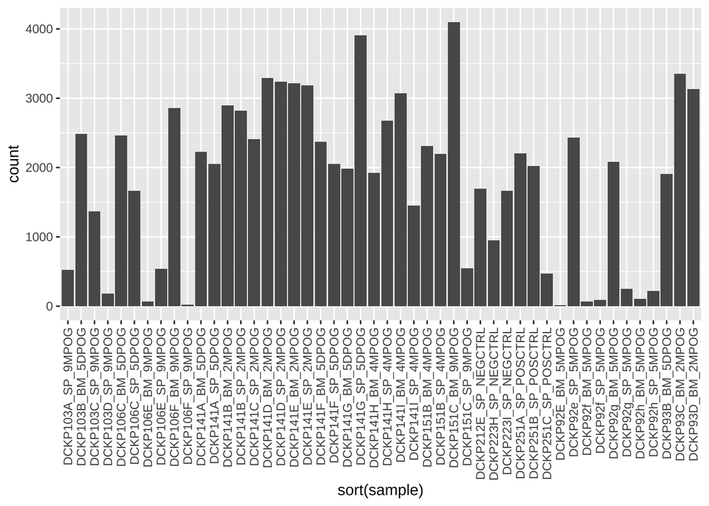

```r
my.samples <- filenames
my.samples <- gsub("/Volumes/babs/working/goldstr2/projects/caladod/anqi.xu/DN19023-ax343/merged_read_bam/", "", my.samples)
my.samples <- gsub(".bam$", "", my.samples)

# we only want to know about the reads mapped to our locus, so we'll need a GRanges object to limit our search with

region <- gr <- GRanges(seqnames = '12',ranges = IRanges(113428106:113428538))

my.mapped.reads <- data.frame('sample' = my.samples, 'count' = 0) # initialise a df to store our results

for (i in 1:length(filenames)) {
  bamFile <- scanBam(filenames[i], region=region) #read the bam in filename[i]
  my.mapped.reads$count[i] <- length(bamFile[[1]]$qname) #save the number of mapped reads
}

ggplot(my.mapped.reads, aes(x=sort(sample), y=count)) +
  geom_bar(stat="identity") +
  theme(axis.text.x = element_text(angle = 90, vjust = 0.5, hjust=1))
```

There are a few samples with poor read counts, so we will want to be mindful of those as we move through the analysis

```r
my.mapped.reads$sample[which(my.mapped.reads$count < 400 )] ## we'll just look at what samples have less than 400 mapped reads
```

```
## [1] "DCKP103D_SP_9MPOG" "DCKP106E_BM_9MPOG" "DCKP106F_SP_9MPOG"
## [4] "DCKP92E_BM_5MPOG"  "DCKP92f_BM_5MPOG"  "DCKP92f_SP_5MPOG"
## [7] "DCKP92g_SP_5MPOG"  "DCKP92h_BM_5MPOG"  "DCKP92h_SP_5MPOG"
```

We’ll export a table with these counts in case you need them later.

```r
write.csv(my.mapped.reads, 'r_output_files/mapped_reads_count.csv')
```

## 2.2 Calling variants with Mutect2 and producing vcf files

Mutect2 is a somatic variant caller

```bash
#!/usr/bin/bash

module purge
module load GATK/4.1.8.1-GCCcore-9.3.0-Java-1.8

gatk Mutect2 -R $reference \
  -I $sample.bam \
  -L 12:113,428,106-113,428,538 \
  -O vcf/$sample.vcf.gz
```

## 2.3 Counting the variants per sample

Now we’ve produced our vcf files, we can just read them into R and start cruncing the numbers

```r
# read in the list of vcf files (we just want the vcf files so we anchor the pattern with $ at the end)

filenames <- list.files("/Volumes/babs/working/goldstr2/projects/caladod/anqi.xu/DN19023-ax343/vcf", pattern="*.vcf.gz$", full.names=TRUE)
knitr::kable(filenames)
```

| x |
| --- |
| /Volumes/babs/working/goldstr2/projects/caladod/anqi.xu/DN19023-ax343/vcf/DCKP103A_SP_9MPOG.vcf.gz |
| /Volumes/babs/working/goldstr2/projects/caladod/anqi.xu/DN19023-ax343/vcf/DCKP103B_BM_5DPOG.vcf.gz |
| /Volumes/babs/working/goldstr2/projects/caladod/anqi.xu/DN19023-ax343/vcf/DCKP103C_SP_9MPOG.vcf.gz |
| /Volumes/babs/working/goldstr2/projects/caladod/anqi.xu/DN19023-ax343/vcf/DCKP103D_SP_9MPOG.vcf.gz |
| /Volumes/babs/working/goldstr2/projects/caladod/anqi.xu/DN19023-ax343/vcf/DCKP106C_BM_5DPOG.vcf.gz |
| /Volumes/babs/working/goldstr2/projects/caladod/anqi.xu/DN19023-ax343/vcf/DCKP106C_SP_5DPOG.vcf.gz |
| /Volumes/babs/working/goldstr2/projects/caladod/anqi.xu/DN19023-ax343/vcf/DCKP106E_BM_9MPOG.vcf.gz |
| /Volumes/babs/working/goldstr2/projects/caladod/anqi.xu/DN19023-ax343/vcf/DCKP106E_SP_9MPOG.vcf.gz |
| /Volumes/babs/working/goldstr2/projects/caladod/anqi.xu/DN19023-ax343/vcf/DCKP106F_BM_9MPOG.vcf.gz |
| /Volumes/babs/working/goldstr2/projects/caladod/anqi.xu/DN19023-ax343/vcf/DCKP106F_SP_9MPOG.vcf.gz |
| /Volumes/babs/working/goldstr2/projects/caladod/anqi.xu/DN19023-ax343/vcf/DCKP141A_BM_5DPOG.vcf.gz |
| /Volumes/babs/working/goldstr2/projects/caladod/anqi.xu/DN19023-ax343/vcf/DCKP141A_SP_5DPOG.vcf.gz |
| /Volumes/babs/working/goldstr2/projects/caladod/anqi.xu/DN19023-ax343/vcf/DCKP141B_BM_2MPOG.vcf.gz |
| /Volumes/babs/working/goldstr2/projects/caladod/anqi.xu/DN19023-ax343/vcf/DCKP141B_SP_2MPOG.vcf.gz |
| /Volumes/babs/working/goldstr2/projects/caladod/anqi.xu/DN19023-ax343/vcf/DCKP141C_SP_2MPOG.vcf.gz |
| /Volumes/babs/working/goldstr2/projects/caladod/anqi.xu/DN19023-ax343/vcf/DCKP141D_BM_2MPOG.vcf.gz |
| /Volumes/babs/working/goldstr2/projects/caladod/anqi.xu/DN19023-ax343/vcf/DCKP141D_SP_2MPOG.vcf.gz |
| /Volumes/babs/working/goldstr2/projects/caladod/anqi.xu/DN19023-ax343/vcf/DCKP141E_BM_2MPOG.vcf.gz |
| /Volumes/babs/working/goldstr2/projects/caladod/anqi.xu/DN19023-ax343/vcf/DCKP141E_SP_2MPOG.vcf.gz |
| /Volumes/babs/working/goldstr2/projects/caladod/anqi.xu/DN19023-ax343/vcf/DCKP141F_BM_5DPOG.vcf.gz |
| /Volumes/babs/working/goldstr2/projects/caladod/anqi.xu/DN19023-ax343/vcf/DCKP141F_SP_5DPOG.vcf.gz |
| /Volumes/babs/working/goldstr2/projects/caladod/anqi.xu/DN19023-ax343/vcf/DCKP141G_BM_5DPOG.vcf.gz |
| /Volumes/babs/working/goldstr2/projects/caladod/anqi.xu/DN19023-ax343/vcf/DCKP141G_SP_5DPOG.vcf.gz |
| /Volumes/babs/working/goldstr2/projects/caladod/anqi.xu/DN19023-ax343/vcf/DCKP141H_BM_4MPOG.vcf.gz |
| /Volumes/babs/working/goldstr2/projects/caladod/anqi.xu/DN19023-ax343/vcf/DCKP141H_SP_4MPOG.vcf.gz |
| /Volumes/babs/working/goldstr2/projects/caladod/anqi.xu/DN19023-ax343/vcf/DCKP141I_BM_4MPOG.vcf.gz |
| /Volumes/babs/working/goldstr2/projects/caladod/anqi.xu/DN19023-ax343/vcf/DCKP141I_SP_4MPOG.vcf.gz |
| /Volumes/babs/working/goldstr2/projects/caladod/anqi.xu/DN19023-ax343/vcf/DCKP151B_BM_4MPOG.vcf.gz |
| /Volumes/babs/working/goldstr2/projects/caladod/anqi.xu/DN19023-ax343/vcf/DCKP151B_SP_4MPOG.vcf.gz |
| /Volumes/babs/working/goldstr2/projects/caladod/anqi.xu/DN19023-ax343/vcf/DCKP151C_BM_9MPOG.vcf.gz |
| /Volumes/babs/working/goldstr2/projects/caladod/anqi.xu/DN19023-ax343/vcf/DCKP151C_SP_9MPOG.vcf.gz |
| /Volumes/babs/working/goldstr2/projects/caladod/anqi.xu/DN19023-ax343/vcf/DCKP212E_SP_NEGCTRL.vcf.gz |
| /Volumes/babs/working/goldstr2/projects/caladod/anqi.xu/DN19023-ax343/vcf/DCKP223H_SP_NEGCTRL.vcf.gz |
| /Volumes/babs/working/goldstr2/projects/caladod/anqi.xu/DN19023-ax343/vcf/DCKP223I_SP_NEGCTRL.vcf.gz |
| /Volumes/babs/working/goldstr2/projects/caladod/anqi.xu/DN19023-ax343/vcf/DCKP251A_SP_POSCTRL.vcf.gz |
| /Volumes/babs/working/goldstr2/projects/caladod/anqi.xu/DN19023-ax343/vcf/DCKP251B_SP_POSCTRL.vcf.gz |
| /Volumes/babs/working/goldstr2/projects/caladod/anqi.xu/DN19023-ax343/vcf/DCKP251C_SP_POSCTRL.vcf.gz |
| /Volumes/babs/working/goldstr2/projects/caladod/anqi.xu/DN19023-ax343/vcf/DCKP92E_BM_5MPOG.vcf.gz |
| /Volumes/babs/working/goldstr2/projects/caladod/anqi.xu/DN19023-ax343/vcf/DCKP92e_SP_5MPOG.vcf.gz |
| /Volumes/babs/working/goldstr2/projects/caladod/anqi.xu/DN19023-ax343/vcf/DCKP92f_BM_5MPOG.vcf.gz |
| /Volumes/babs/working/goldstr2/projects/caladod/anqi.xu/DN19023-ax343/vcf/DCKP92f_SP_5MPOG.vcf.gz |
| /Volumes/babs/working/goldstr2/projects/caladod/anqi.xu/DN19023-ax343/vcf/DCKP92g_BM_5MPOG.vcf.gz |
| /Volumes/babs/working/goldstr2/projects/caladod/anqi.xu/DN19023-ax343/vcf/DCKP92g_SP_5MPOG.vcf.gz |
| /Volumes/babs/working/goldstr2/projects/caladod/anqi.xu/DN19023-ax343/vcf/DCKP92h_BM_5MPOG.vcf.gz |
| /Volumes/babs/working/goldstr2/projects/caladod/anqi.xu/DN19023-ax343/vcf/DCKP92h_SP_5MPOG.vcf.gz |
| /Volumes/babs/working/goldstr2/projects/caladod/anqi.xu/DN19023-ax343/vcf/DCKP93B_BM_5DPOG.vcf.gz |
| /Volumes/babs/working/goldstr2/projects/caladod/anqi.xu/DN19023-ax343/vcf/DCKP93C_BM_2MPOG.vcf.gz |
| /Volumes/babs/working/goldstr2/projects/caladod/anqi.xu/DN19023-ax343/vcf/DCKP93D_BM_2MPOG.vcf.gz |

```r
# also get a vector of just the names for later

my.samples <- filenames
my.samples <- gsub("/Volumes/babs/working/goldstr2/projects/caladod/anqi.xu/DN19023-ax343/vcf/", "", my.samples)
my.samples <- gsub(".vcf.gz", "", my.samples)

my.vcf.counts <- vector(length=length(my.samples)) ## initialise a vector where we will store our counts
my.vfs <- data.frame()
my.melted.table <- data.frame()

for (i in 1:length(filenames)) { ## loop over the VCF files and get the number of variants in each sample
  vcf <- read.vcfR(filenames[i], verbose = FALSE) # reads the vcf file using vcfR
  f <- getFIX(vcf) # gets a table of the called variants
  dp <- as.vector(extract.gt(vcf, element="DP", as.numeric=TRUE))
  if ( length(dp) > 0 ) {
    my.vfs <- rbind(my.vfs, cbind(my.samples[i], dp / my.mapped.reads$count[which( my.mapped.reads$sample == my.samples[i] )]))
  }
  if (length(dim(f)) > 0 ) {
    my.vcf.counts[i] <- length(f[,"CHROM"]) # the number of rows in f are the number of variants detected in the sample
    if (dim(f)[1] > 0) {
      my.melted.table <- rbind(my.melted.table, cbind(paste(f[,'CHROM'], f[,'POS'], f[,'REF'], f[,'ALT'], sep = "-"), my.samples[i], dp))
    }
  } else {
    my.vcf.counts[i] <- length(f["CHROM"])
  }
}

names(my.vcf.counts) <- my.samples
my.vcf.counts <- data.frame('sample' = names(my.vcf.counts), 'count' = my.vcf.counts)

my.cast.table <- dcast(my.melted.table,formula = V2~V1)
my.cast.table <- my.cast.table[,-1]
my.cast.table <- as.data.frame(sapply(my.cast.table, as.numeric))
rownames(my.cast.table) <- dcast(my.melted.table,formula = V2~V1)[,1]

my.cast.table <- setnafill(my.cast.table, fill = 0) # replace the NAs with 0 as it's the same thing
```

As the output of this process, we have a couple of datasets to explore.

the first. `my.vcf.counts` is a data frame of samples and the number of variants found

The second, `my.cast.table` is a matrix of strains vs variants with the values showing the number of reads per variant

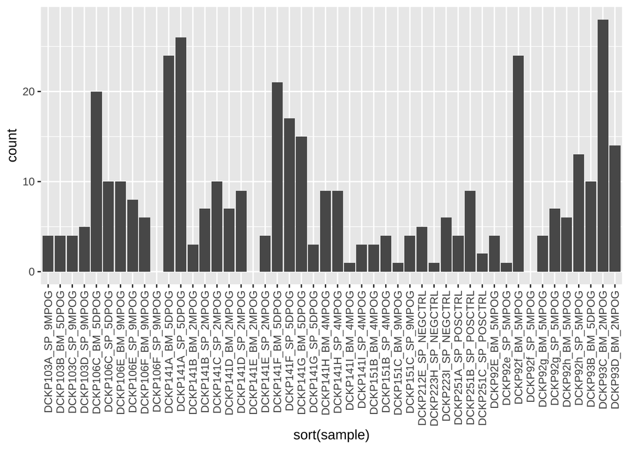

```r
## Let's take a look at the number of variants found

ggplot(my.vcf.counts, aes(x=sort(sample), y=count)) +
  geom_bar(stat="identity") +
  theme(axis.text.x = element_text(angle = 90, vjust = 0.5, hjust=1))
```

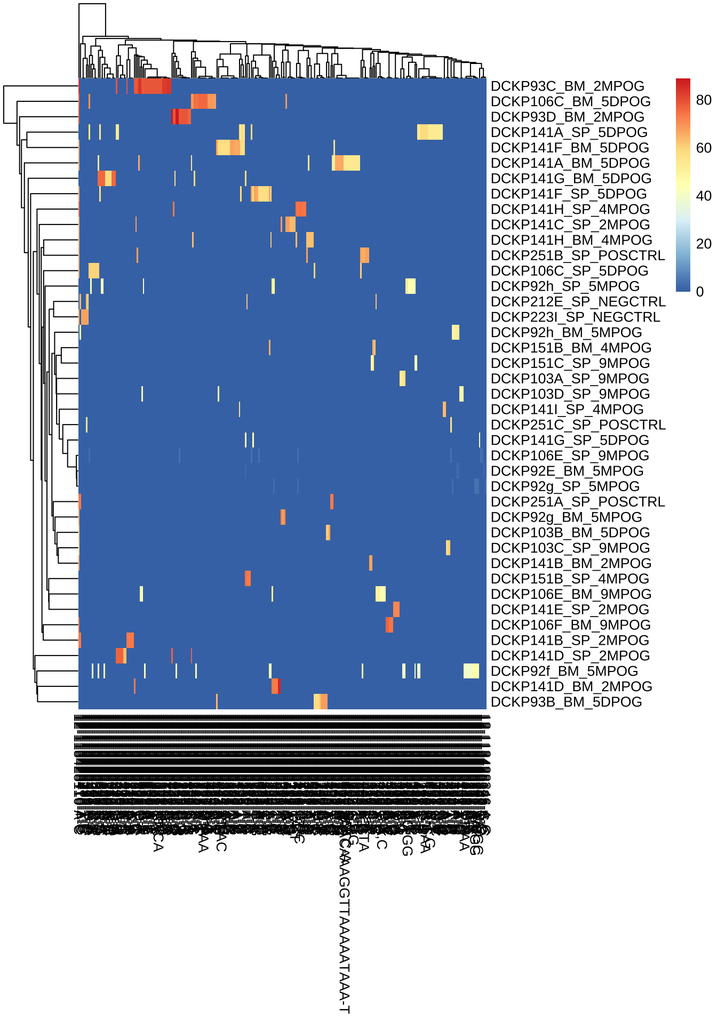

```r
## and we can use a heatmap to show the distribution of variants

pheatmap(my.cast.table) # show a heatmap of these values
```

```r
# we'll save that.

write.csv(my.cast.table, 'r_output_files/mutect2_variant_matrix.csv')
```

This data can be further explored to see if there is anything going on

Next, we can have a look at if the number of mapped reads correlates with the called variants

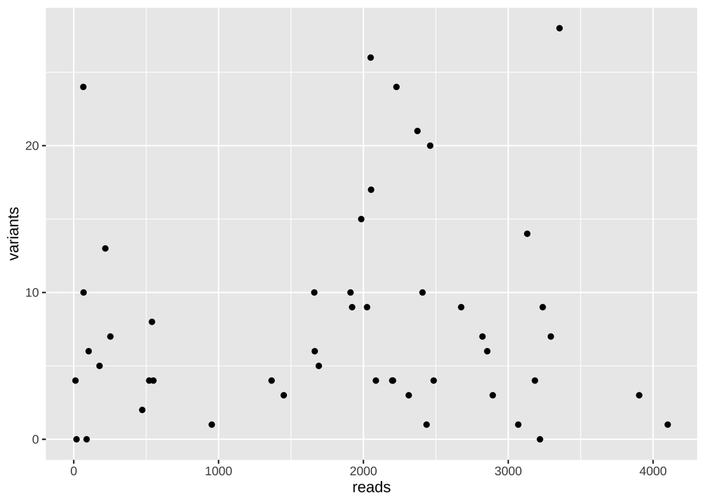

```r
reads.vs.variants <- cbind(my.mapped.reads,my.vcf.counts$count)
colnames(reads.vs.variants) <- c('sample', 'reads', 'variants')
ggplot(reads.vs.variants, aes(x=reads, y=variants)) + geom_point()
```

It doesn’t look like reads and variants are related at all, so I guess that means whatever Mutect2 is doing it has done it ok

Next we can look at the vfs between the samples, a violin plot will do nicely

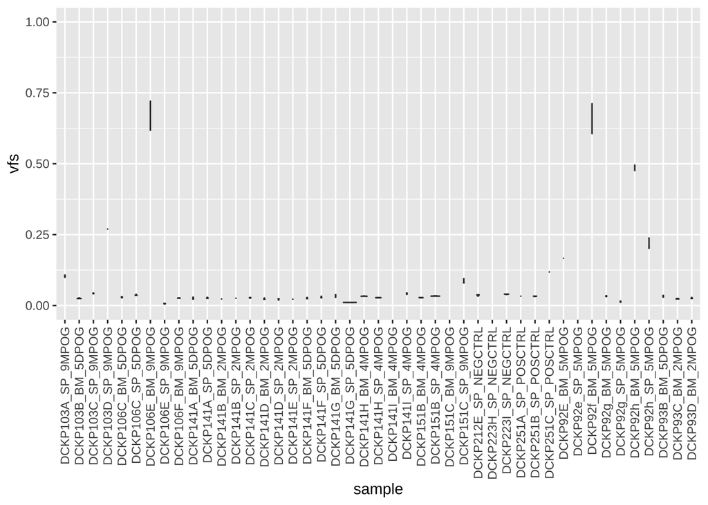

```r
colnames(my.vfs) <- c('sample', 'vfs')
my.vfs$vfs <- as.numeric(my.vfs$vfs)

ggplot(my.vfs, aes(x=sample, y=vfs)) +
  geom_violin() +
  theme(axis.text.x = element_text(angle = 90, vjust = 0.5, hjust=1)) +
  ylim(c(0,1))
```

Some of the samples have very high variant frequency scores. This is suggesting that, in these samples, most of the variants they have are common in the samples. It could suggest a problem with those samples.

Let’s take a look at the correlation of vfs and read count

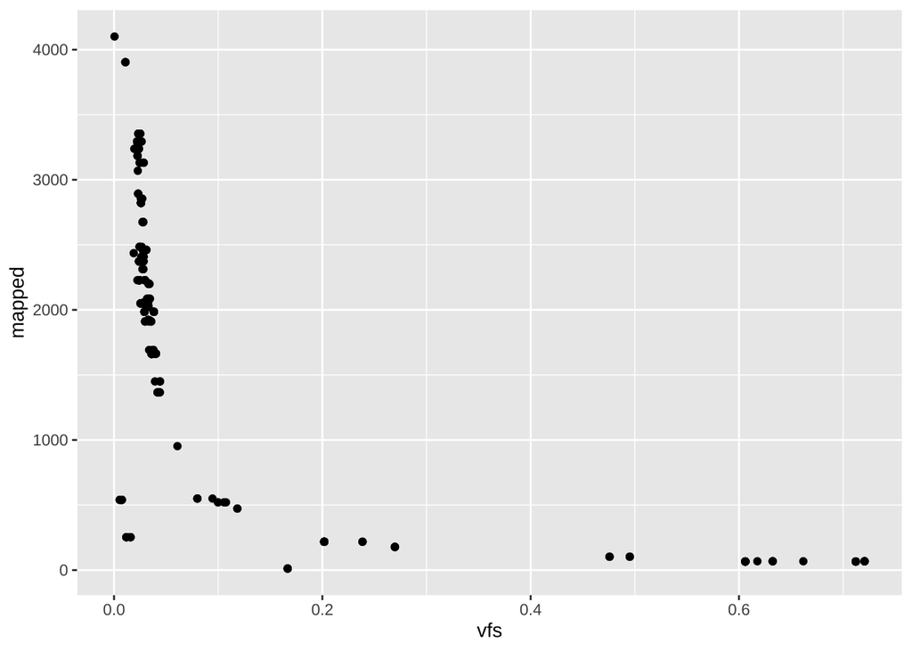

```r
my.data <- data.frame('sample' = my.mapped.reads$sample[match(my.vfs$sample, my.mapped.reads$sample)], 'vfs' = my.vfs$vfs, 'mapped' = my.mapped.reads$count[match(my.vfs$sample, my.mapped.reads$sample)])

ggplot(my.data, aes(x=vfs, y=mapped)) + geom_point()
```

So we are picking up more low frequency variants with more sequencing depth. Only variants with low mapped reads have high vfs- these may be PCR artifacts

We can see who the problematic samples are by looking at who has mapping less than 400 reads

```r
my.mapped.reads$sample[which(my.mapped.reads$count < 400 )] ## we'll just look at what samples have less than 400 mapped reads
```

```
## [1] "DCKP103D_SP_9MPOG" "DCKP106E_BM_9MPOG" "DCKP106F_SP_9MPOG"
## [4] "DCKP92E_BM_5MPOG"  "DCKP92f_BM_5MPOG"  "DCKP92f_SP_5MPOG"
## [7] "DCKP92g_SP_5MPOG"  "DCKP92h_BM_5MPOG"  "DCKP92h_SP_5MPOG"
```

Let’s remove these, and then look at some groups

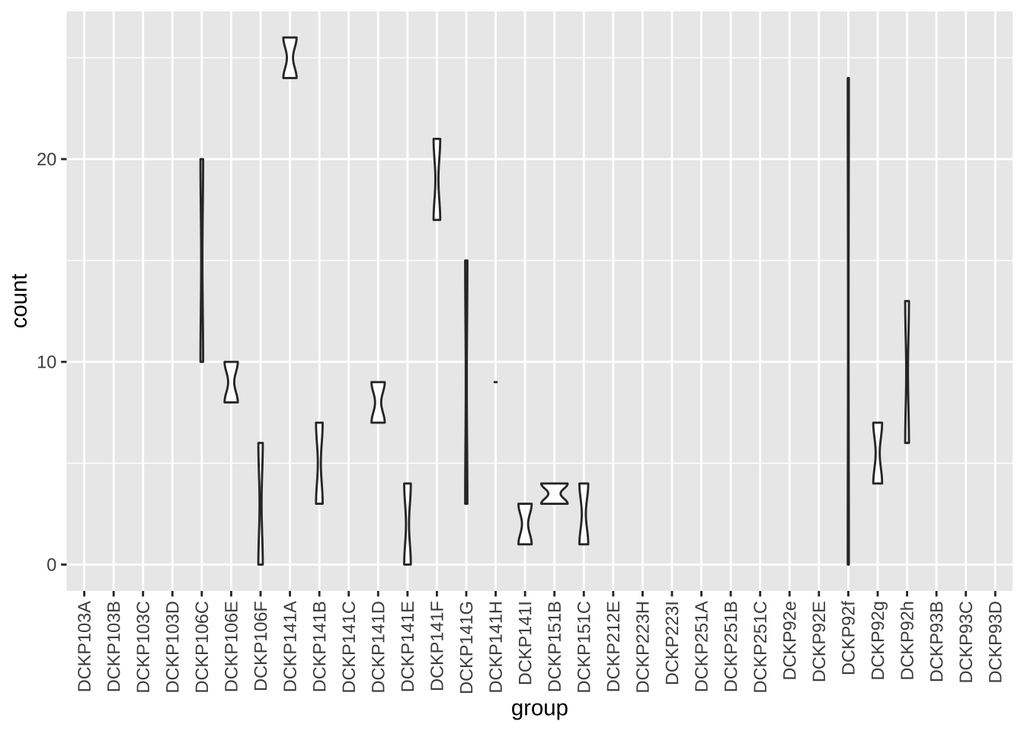

```r
my.mod.vcf.counts <- my.vcf.counts[,-match(my.mapped.reads$sample[which(my.mapped.reads$count < 400 )], my.vcf.counts$sample)]

mice <- unique(sapply(strsplit(rownames(my.vcf.counts), split="_"),"[[",1))
tissue <- unique(sapply(strsplit(rownames(my.vcf.counts), split="_"),"[[",2))
drug <- unique(sapply(strsplit(rownames(my.vcf.counts), split="_"),"[[",3))

get.counts <- function(x, vcf.object) {
  o <- data.frame('group' = character(), 'count' = numeric())
  for (i in 1:length(x)) {
    d <- as.data.frame(cbind(x[i],vcf.object[grep(paste(x[i], "", sep=""), rownames(vcf.object)),'count']))
    colnames(d) <- c('group', 'count')
    d$count <- as.numeric(d$count)
    o <- rbind(o,d)
  }
  return(o)
}

mice.data <- get.counts(mice, my.mod.vcf.counts)
tissue.data <- get.counts(tissue, my.mod.vcf.counts)
drug.data <- get.counts(drug, my.mod.vcf.counts)

ggplot(mice.data, aes(x=group, y=count)) +
  geom_violin() +
  theme(axis.text.x = element_text(angle = 90, vjust = 0.5, hjust=1))
```

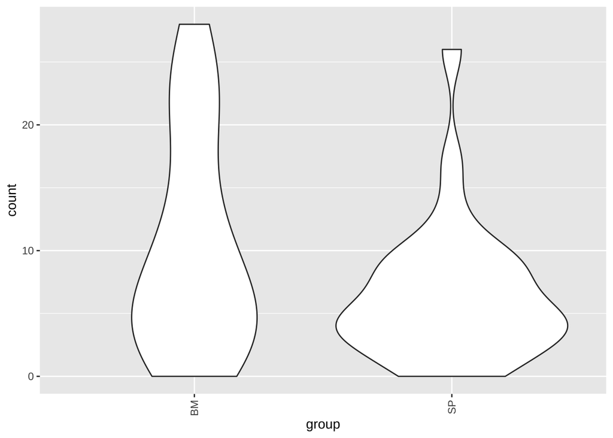

```r
ggplot(tissue.data, aes(x=group, y=count)) +
  geom_violin() +
  theme(axis.text.x = element_text(angle = 90, vjust = 0.5, hjust=1))
```

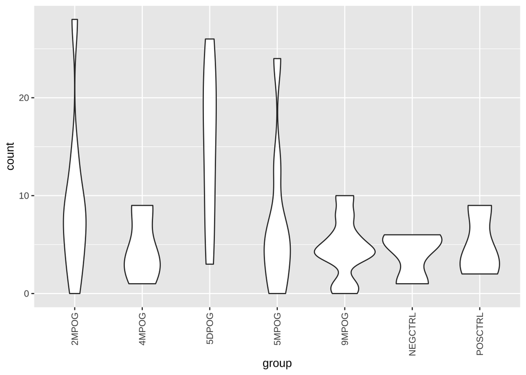

```r
ggplot(drug.data, aes(x=group, y=count)) +
  geom_violin() +
  theme(axis.text.x = element_text(angle = 90, vjust = 0.5, hjust=1))
```